# Personalized Imputation in metric spaces via conformal prediction: Applications in Predicting Diabetes Development with Continuous Glucose Monitoring Information

Marcos Matabuena

Carla Díaz-Louzao

Rahul Ghosal

Francisco Gude-Sampedro

26 March, 2024

# 1 Introduction

In this document, we show the missing data model fit for the glucodensities on the 580 AEGIS-I subjects at baseline. As there are a total of 1516 subjects, once we fitted the model, we imputed the glucodensities on the remaining 936 subjects. All glucodensities (actual and imputed) will subsequently be used for the estimation of diabetes incidence as well as diabetes survival.

```r
rm(list = ls())

###################################################################################################################
################################################ LOADING LIBRARIES ################################################
###################################################################################################################
library(cowplot)
library(dplyr)
library(gridExtra)
library(kableExtra)
library(mgcv)
library(OptimalCutpoints)
library(pROC)
library(readxl)
library(risksetROC)
library(rms)
library(tidymv)

source("I:/Conformal_Imputation_Glucodensities/Scripts/functions.R")
source("I:/Conformal_Imputation_Glucodensities/Scripts/glucodensities_missing.R")
```

```r
###################################################################################################################
################################################# READING THE DATA ################################################
###################################################################################################################

##' For each patient with continuous glucose monitoring (CGM), there is a .csv file. Here we obtain the names of
##' all the files containing the data
dat = list.files("I:/Conformal_Imputation_Glucodensities/Datos/csv_monitorización_AI/", full.names = TRUE)

##' We join the .csv files
tmp <- list()
for (i in 1:length(dat)){
  tmp[[i]] <- fread(dat[i])
}
rm(i)
rm(dat)
dato <- rbindlist(tmp, fill = TRUE)
rm(tmp)

##' We rename the columns "Día", "Fecha", "Hora", and "Glucosa" to English.
dato <- dato %>% rename(Day = "D\xeda",  Date = "Fecha", Time = "Hora", Glucose = "Glucosa")

##' We select the variables we are interested in and create "DateTime".
data <- dato %>% dplyr::select(ID, Day, Date, Time, Glucose) %>%
  mutate(DateTime = as_datetime(paste(Date, Time, sep = " "), format="%d/%m/%Y %H:%M:%S"))
rm(dato)
##' We set the seconds to 0
second(data$DateTime) <- 0

##' We create a variable indicating the phase of the AEGIS study in which the data were taken. This data were
##' taken at baseline, so we name the phase as "AI"
data <- data %>% mutate(Phase = "AI")
# View(data)

##' We load the baseline data
datos1 <- read_excel("I:/Conformal_Imputation_Glucodensities/Datos/baseline.xlsx")
datos1 <- as.data.frame(datos1)

##' We joint the data
data1 <- right_join(data, datos1, by = c("ID" = "id"))
rm(data)
rm(datos1)
data1 <- data1[order(data1$ID), ]

##' We set the variable "ID" as a factor
data1$ID <- as.factor(data1$ID)
# View(data1)

data1 <- as.data.frame(data1)

##' Database with one row per individual
data1_id <- data1[!duplicated(data1$ID), ]
# names(data1_id)

##' Rename the variables of the database
data1_id$Age <- data1_id$edad
data1_id$BMI <- data1_id$bmi
data1_id$HbA1c <- data1_id$a1c
data1_id$FPG <- data1_id$glu
data1_id$Albumin <- data1_id$alb
data1_id$Insulin <- data1_id$Ins
data1_id$Sex <- as.factor(ifelse(data1_id$sex == 0, "Female", "Male"))
data1_id$Smoking <- factor(ifelse(data1_id$tab012 == 0, "Never",
                                  ifelse(data1_id$tab012 == 1, "Ex-smoker", "Smoker")),
                           levels = c("Never", "Ex-smoker", "Smoker"))
data1_id$DM <- as.factor(ifelse(data1_id$dm1_bin == 0, "No", "Yes"))
data1_id$cgm <- as.factor(1*!is.na(data1_id$Day))
data1_id$CGM <- as.factor(ifelse(data1_id$cgm == 0, "No", "Yes"))
```

# 2 Details of Covariates

A total of 1516 individuals were chosen for our analyses with Continuous Glucose Monitoring (CGM) available for 580 individuals between 1 and 5 days. The covariates used in the models include sociodemographic and clinical variables such as Age, Body Mass Index (BMI, $kg/m^2$), glycated haemoglobin (HbA1c, %), baseline Fasting Plasma Glucose (FPG, $mmol/L$), Insuline, and Albumin, along with the categorical variables Sex, Smoking habits and presence or absence of Diabetes melitus ($DM$). Age at the baseline moment (AEGIS-I) was in the range 18 to 91 years. Overall, there are 183 (12.07%) of individuals with $DM$ at baseline.

To understand the distribution of the covariates between the levels of the Sex variable, we constructed Table 2.1.

```r
data1_id_all <- data1_id[, c("CGM", "Age", "BMI", "HbA1c", "FPG", "Albumin", "Insulin", "Smoking", "DM", "Sex")]
data1_id_all$type <- "Total Sample"
data1_id_cgm <- data1_id_all[data1_id_all$CGM == "Yes", ]
data1_id_cgm$type <- "CGM"
data1_id_ncgm <- data1_id_all[data1_id_all$CGM == "No", ]
data1_id_ncgm$type <- "Not CGM"

datos <- rbind.data.frame(data1_id_all, data1_id_cgm, data1_id_ncgm)
rm(data1_id_all)
datos$type <- factor(datos$type, levels = c("Total Sample", "CGM", "Not CGM"))

datos_cont <- datos[, c("Age", "BMI", "HbA1c", "FPG", "Albumin", "Insulin", "type", "Sex")]
n <- desc_cont(variables = "Age", covariate = "Sex", siteid = "type", datos = datos_cont, digits = 2, pvalue = F, n = F, median = F)[[2]]

nombres <- c("Age", "BMI", "HbA1c", "FPG", "Albumin", "Insulin")
tabla_cont <- desc_cont(variables = nombres, covariate = "Sex", siteid = "type", datos = datos_cont, digits = 2, pvalue = F, n = F, median = F)[[1]]


datos_cat <- datos[, c("Smoking", "DM", "Sex", "type")]
tabla_cat <- desc_cat(datos = datos_cat, variables = c("Smoking", "DM"), covariate = "Sex", siteid = "type", n = F, pvalue = F)[[1]]
tabla_cat <- tabla_cat[c(1:3, 5), ]
tabla_cat[1, ] <- c("Smoking", "", "", "", "", "", "")
tabla_cat[, 1] <- c("Smoking", "Ex-smoker", "Smoker", "DM")

colnames(tabla_cont) <- colnames(tabla_cat)
tabla <- rbind.data.frame(tabla_cont, tabla_cat)
names(tabla) <- c(" ", "Female", "Male", "Female ", "Male ", "Female  ", "Male  ")
```

Table 2.1: Table 2.2: Summary of the predictor variables used in the regression analysis, for the whole sample and separated by Sex and the fact of having or not CGM at baseline. We represent the means and the standard deviations (in brackets) of the continuous variables (Age, BMI, HbA1c, FPG, Albumin, Insulin) for Female and Male with and without CGM at baseline. For the categorical variables Smoking and DM, we include the absolute frequency and percentage (in brackets).

|  | Total sample Female | Total sample Male | CGM Female | CGM Male | No CGM Female | No CGM Male |
| --- | --- | --- | --- | --- | --- | --- |
| Age | 53.09 (17.52) | 51.97 (17.58) | 48.21 (14.48) | 47.85 (14.79) | 56.76 (18.69) | 53.96 (18.47) |
| BMI | 27.99 (5.40) | 28.56 (4.64) | 27.71 (5.33) | 28.92 (4.74) | 28.19 (5.46) | 28.39 (4.59) |
| HbA1c | 5.57 (0.65) | 5.65 (0.83) | 5.52 (0.69) | 5.64 (0.88) | 5.62 (0.62) | 5.66 (0.81) |
| FPG | 92.05 (21.03) | 97.54 (24.50) | 90.96 (20.85) | 97.06 (23.37) | 92.87 (21.15) | 97.78 (25.04) |
| Albumin | 4.35 (0.22) | 4.48 (0.25) | 4.36 (0.21) | 4.51 (0.23) | 4.35 (0.22) | 4.46 (0.25) |
| Insulin | 11.69 (7.31) | 14.02 (13.50) | 11.69 (7.41) | 15.54 (18.41) | 11.69 (7.24) | 13.29 (10.29) |
| Smoking |  |  |  |  |  |  |
| Ex-smoker | 128 (15.27%) | 267 (39.38%) | 77 (21.39%) | 77 (35.00%) | 51 (10.67%) | 190 (41.48%) |
| Smoker | 124 (14.80%) | 172 (25.37%) | 62 (17.22%) | 56 (25.45%) | 62 (12.97%) | 116 (25.33%) |
| DM | 82 (9.79%) | 101 (14.90%) | 31 (8.61%) | 33 (15.00%) | 51 (10.67%) | 68 (14.85%) |

In Figure 2.1 we show the boxplots for the continuous variables for the overall data set, while in Figure 2.2 we show the boxplots for the continuous variables for the 580 individuals with CGM measurements.

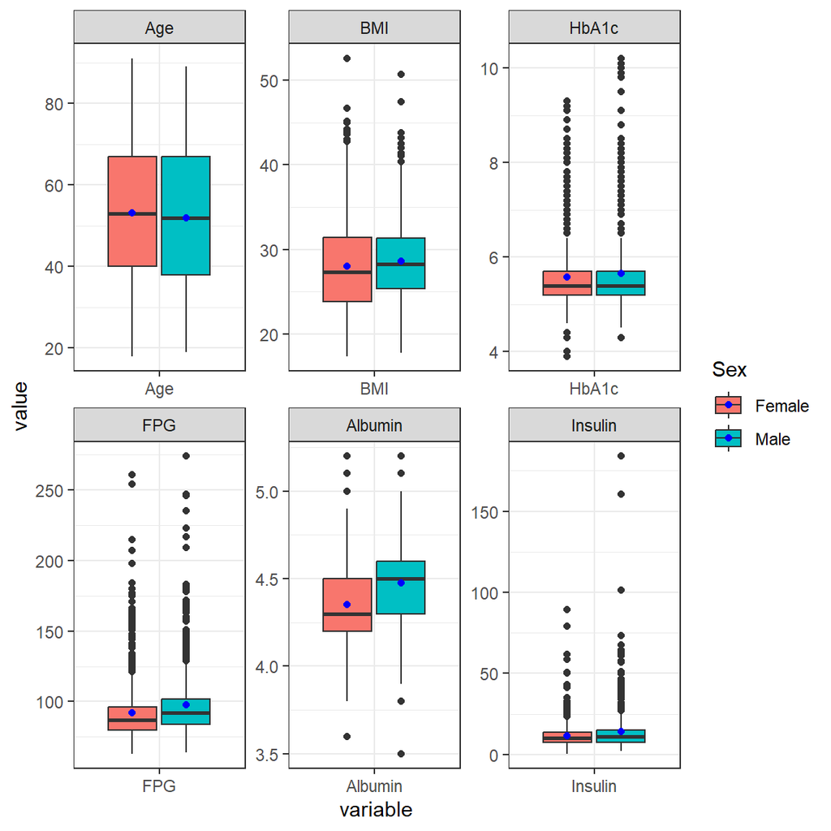

Figure 2.1: Boxplot for the continuous variables for the complete data set, separating by sex. The blue point indicates the mean value.

```r
plot_cont(data1_id[, c("Age", "BMI", "HbA1c", "FPG", "Albumin", "Insulin")], data1_id$Sex, nvar = "Sex")
```

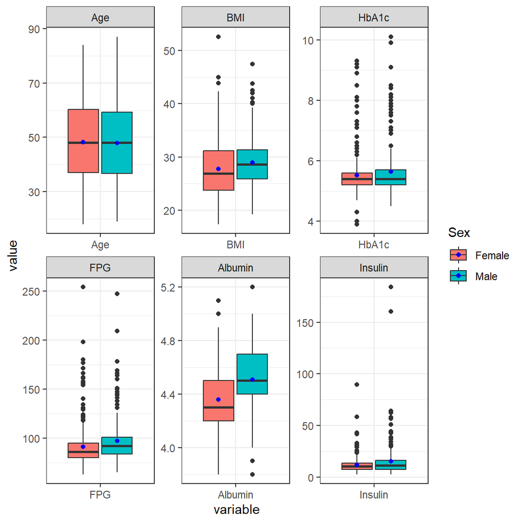

Figure 2.2: Boxplot for the continuous variables for the individuals with CGM measurements, separating by sex. The blue point indicates the mean value.

```r
plot_cont(data1_id_cgm[, c("Age", "BMI", "HbA1c", "FPG", "Albumin", "Insulin")], data1_id_cgm$Sex, nvar = "Sex")
```

# 3 Glucodensities estimation at baseline (AEGIS I). Imputation of missing responses using inverse probably weighting estimator

In this Section, we are going to fit the missing data model using the baseline information from the 1516 subjects in the AEGIS-I study. The variables we want to use are “Age”, “Sex”, “HbA1c”, “FPG”, “Smoking” habits, “Albumin”, and “BMI”.

## 3.1 Computing the weights

As a first step, we are going to assign a “0” to the subjects without continuous glucose monitoring (CGM) and a “1” with CGM. In Table 3.1, the proportion of subjects without and with CGM at baseline is shown.

```r
cgm <- round(prop.table(table(data1_id$cgm)), 3)
```

Table 3.1: Table 3.2: Proportion of subjects with CGM in AEGIS-I.

| CGM | Proportion |
| --- | --- |
| 0 = No | 0.617 |
| 1 = Yes | 0.383 |

Second, we are going to estimate the probability of non being missing, as a function of Age, Sex, HbA1c, FPG, Smoking habits, Albumin, and BMI. For that, we fit a logistic GAM regression model (Wood 2017).

```r
mod <- gam(cgm ~ s(Age) + Sex + s(HbA1c) + s(FPG) + Smoking + s(Albumin) + s(BMI), data = data1_id, family = binomial)
summary(mod)
```

```
##
## Family: binomial
## Link function: logit
##
## Formula:
## cgm ~ s(Age) + Sex + s(HbA1c) + s(FPG) + Smoking + s(Albumin) +
##     s(BMI)
##
## Parametric coefficients:
##                  Estimate Std. Error z value Pr(>|z|)
## (Intercept)      -0.34936    0.08853  -3.946 7.94e-05 ***
## SexMale          -0.60176    0.12960  -4.643 3.43e-06 ***
## SmokingEx-smoker  0.11597    0.14433   0.804    0.422
## SmokingSmoker    -0.14805    0.15522  -0.954    0.340
## ---
## Signif. codes:  0 '***' 0.001 '**' 0.01 '*' 0.05 '.' 0.1 ' ' 1
##
## Approximate significance of smooth terms:
##              edf Ref.df Chi.sq p-value
## s(Age)     5.865  6.951 92.642 < 2e-16 ***
## s(HbA1c)   5.106  6.208 17.379 0.00944 **
## s(FPG)     2.862  3.620  6.184 0.13879
## s(Albumin) 1.254  1.471  0.729 0.66948
## s(BMI)     1.310  1.566  1.464 0.28358
## ---
## Signif. codes:  0 '***' 0.001 '**' 0.01 '*' 0.05 '.' 0.1 ' ' 1
##
## R-sq.(adj) =  0.107   Deviance explained = 10.1%
## UBRE = 0.22265  Scale est. = 1         n = 1516
```

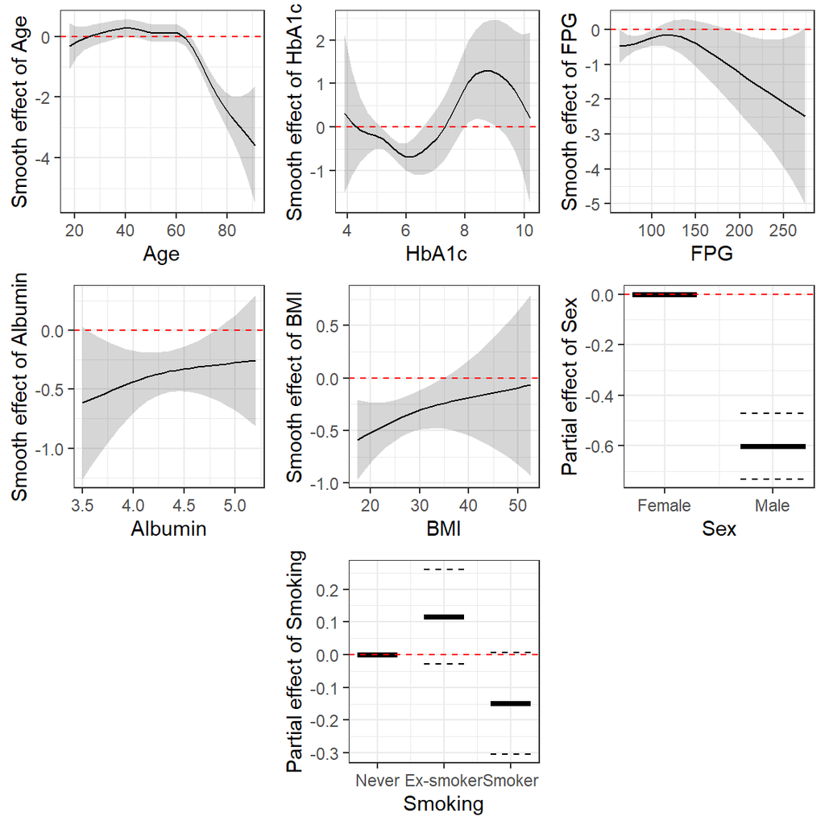

Figure 3.1: Smooth effect of “Age”, “HbA1c”, “FPG”, “Albumin”, “BMI”, “Sex”, and “Smoking” on the probability of having GCM.

```r
p1 <- plot_smooths(
model = mod,
series = Age,
# conditions = quos(Sex == "Woman" & Smoking == "Never"),
exclude_terms = c("Sex", "Smoking", "s(HbA1c)", "s(FPG)", "Smoking", "s(Albumin)", "s(BMI)")
) + theme_bw() +
labs(x = "Age", y = "Smooth effect of Age") +
geom_hline(yintercept = 0, linetype = "dashed", color = "red")

p2 <- plot_smooths(
model = mod,
series = HbA1c,
exclude_terms = c("Sex", "Smoking", "s(Age)", "s(FPG)", "Smoking", "s(Albumin)", "s(BMI)")
) + theme_bw() +
labs(x = "HbA1c", y = "Smooth effect of HbA1c") +
geom_hline(yintercept = 0, linetype = "dashed", color = "red")

p3 <- plot_smooths(
model = mod,
series = FPG,
exclude_terms = c("Sex", "Smoking", "s(Age)", "s(HbA1c)", "Smoking", "s(Albumin)", "s(BMI)")
) + theme_bw() +
labs(x = "FPG", y = "Smooth effect of FPG") +
geom_hline(yintercept = 0, linetype = "dashed", color = "red")

p4 <- plot_smooths(
model = mod,
series = Albumin,
exclude_terms = c("Sex", "Smoking", "s(Age)", "s(HbA1c)", "Smoking", "s(FPG)", "s(BMI)")
) + theme_bw() +
labs(x = "Albumin", y = "Smooth effect of Albumin") +
geom_hline(yintercept = 0, linetype = "dashed", color = "red")

p5 <- plot_smooths(
model = mod,
series = BMI,
exclude_terms = c("Sex", "Smoking", "s(Age)", "s(HbA1c)", "Smoking", "s(Albumin)", "s(FPG)")
) + theme_bw() +
labs(x = "BMI", y = "Smooth effect of BMI") +
geom_hline(yintercept = 0, linetype = "dashed", color = "red")

p <- termplot(mod, terms = "Sex", se = T, plot = F)
Sex <- p$Sex[, -3]
# Sex <- rbind.data.frame(Sex, c("Man", p6$Sex$y[2] - p6$Sex$se[2]))
# Sex <- rbind.data.frame(Sex, c("Man", p6$Sex$y[2] + p6$Sex$se[2]))
Sex$lower <- p$Sex$y - p$Sex$se
Sex$upper <- p$Sex$y + p$Sex$se
p6 <- ggplot(Sex, aes(x, lower)) +
  geom_segment(aes(x=0.7, xend=1.3, y = 0, yend=0), size = 1.25) +
  geom_segment(aes(x=1.7, xend=2.3, y= y[2], yend=y [2]), size = 1.25) +
  labs(x = "Sex", y = "Partial effect of Sex") +
  theme_bw() +
geom_hline(yintercept = 0, linetype = "dashed", color = "red") +
  geom_segment(aes(x=1.7, xend=2.3, y=lower[2], yend=lower[2]), linetype = "dashed") +
  geom_segment(aes(x=1.7, xend=2.3, y=upper[2], yend=upper[2]), linetype = "dashed") +
  scale_x_continuous(breaks = 1:dim(Sex)[1], labels = levels(Sex$x))

p <- termplot(mod, terms = "Smoking", se = T, plot = F)
Smoking <- p$Smoking[, -3]
Smoking$lower <- p$Smoking$y - p$Smoking$se
Smoking$upper <- p$Smoking$y + p$Smoking$se
p7 <- ggplot(Smoking, aes(x, lower)) +
  geom_segment(aes(x=0.7, xend=1.3, y = 0, yend=0), size = 1.25) +
  geom_segment(aes(x=1.7, xend=2.3, y= y[2], yend=y [2]), size = 1.25) +
  geom_segment(aes(x=2.7, xend=3.3, y=y[3], yend=y[3]), size = 1.25) +
  # geom_hpline(aes(y = y), width = 0.6) +
  labs(x = "Smoking", y = "Partial effect of Smoking") +
  theme_bw() +
geom_hline(yintercept = 0, linetype = "dashed", color = "red") +
  geom_segment(aes(x=1.7, xend=2.3, y=lower[2], yend=lower[2]), linetype = "dashed") +
  geom_segment(aes(x=1.7, xend=2.3, y=upper[2], yend=upper[2]), linetype = "dashed") +
  geom_segment(aes(x=2.7, xend=3.3, y=lower[3], yend=lower[3]), linetype = "dashed") +
  geom_segment(aes(x=2.7, xend=3.3, y=upper[3], yend=upper[3]), linetype = "dashed") +
  scale_x_continuous(breaks = 1:dim(Smoking)[1], labels = levels(Smoking$x))
p8 <- ggplot() + theme_void()

grid.arrange(p1, p2, p3, p4, p5, p6, p8, p7, p8, ncol = 3)
```

We then calculated the inverse weights for each subject by taking those with no CGM measurements to 0, and considering the inverse of the fitted values obtained with the previous model and normalizing them for those subjects with CGM measurements.

```r
data1_id$weights <- as.numeric(as.character(data1_id$cgm))/mod$fitted.values
data1_id$weights <- data1_id$weights/sum(data1_id$weights)

weight = data1_id$weights
```

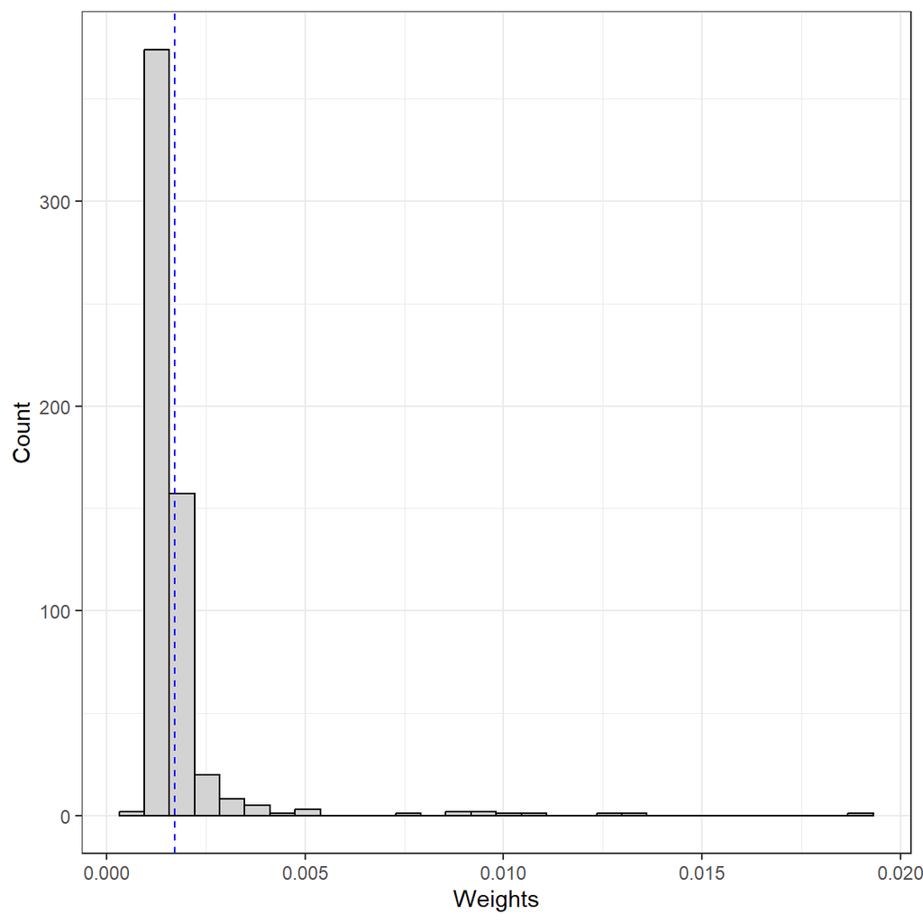

```r
ggplot(data1_id[data1_id$cgm == 1,], aes(x = weights)) +
  geom_histogram(color = "black", fill = "lightgrey") +
  theme_bw() +
  labs(x = "Weights", y = "Count") +
  geom_vline(aes(xintercept = mean(weights)), color="blue",linetype = "dashed")
```

## 3.2 Computing the quantiles of the glucodensities

```r
py = 50 # Length of the grid
Qgrid = seq(0, 1, length = py)
ny = dim(data1_id)[1] # Number of individuals
Qin = matrix(0, ncol = py, nrow = ny)
for(i in 1:ny){
  if(data1_id$cgm[i] == 1){
    Qin[i, ] <- quantile(data1$Glucose[data1$ID == data1_id$ID[i]], probs = Qgrid)
  }
}
rm(i)
```

## 3.3 Selecting the explanatory variables

At this point we have to select the explanatory variables, creating a training data set (“xin”) and a test data set (“xout”), which should be data.frames. In this case, the training and the test databases are going to be the same, and we will include all subjects for the both of them and only the covariates we are interested in (“Age”, “Sex”, “HbA1c”, “FPG”, “Smoking”, “Albumin”, and “BMI”). Since we have two categorical covariates (“Smoking” and “Sex”), we need to use their corresponding dummy variables.

```r
data1_id$tab1 <- ifelse(data1_id$Smoking == "Ex-smoker", 1, 0)
data1_id$tab2 <- ifelse(data1_id$Smoking == "Smoker", 1, 0)

xin = xout = data1_id[, c("Age", "sex", "HbA1c", "FPG", "tab1", "tab2", "Albumin", "BMI")]
px = ncol(xin)
```

## 3.4 Fitting the missing data model

Now that we have computed the weights and the quantiles of the glucodensities and selected the variables, we proceed to fit the model.

```r
m = GloWassRegfinal(xin = xin, Qin = Qin, xout = xout, weight = weight, Qgrid = Qgrid, Rsquared = T)
```

[figure not shown]

The model fitted has a $R^2$ = 0.63, and the estimated coefficients of the model are shown in Figure 3.3.

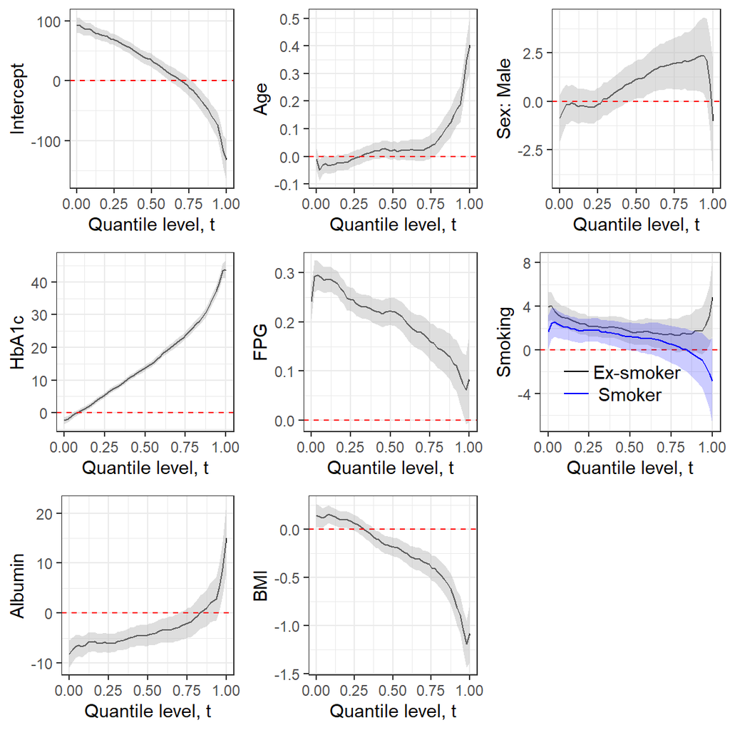

Figure 3.3: Estimated coefficients of the missing data model fitted.

```r
beta = matrix(0, nrow = px + 1, ncol = py)
upper = matrix(0, nrow = px + 1, ncol = py)
lower = matrix(0, nrow = px + 1, ncol = py)

xout <- as.matrix(xout)
for(i in 1:py){
  maux =  lm(Qin[, i] ~ xout[, 1] + xout[, 2] + xout[, 3] + xout[, 4] + xout[, 5] + xout[, 6] + xout[, 7] + xout[, 8],
             weights = weight)
  beta[, i] = maux$coefficients
  upper[, i] = summary(maux)$coefficients[, 1] + summary(maux)$coefficients[, 2]
  lower[, i] = summary(maux)$coefficients[, 1] - summary(maux)$coefficients[, 2]
}

betas <- cbind.data.frame(t(beta), t(upper), t(lower), Qgrid)
names(betas)[1:dim(beta)[1]] <- paste0("v.", 1:dim(beta)[1])
names(betas)[(dim(beta)[1] + 1):(2*dim(beta)[1])] <- paste0("u.", 1:dim(beta)[1])
names(betas)[(2*dim(beta)[1] + 1):(3*dim(beta)[1])] <- paste0("l.", 1:dim(beta)[1])

g1 <- ggplot(data = betas, aes(x = Qgrid, y = v.1))+
  geom_line() +
  geom_ribbon(aes(ymin = l.1, ymax = u.1), fill = "grey",  alpha = 0.5) +
  theme_bw() +
  labs(x = "Quantile level, t", y = "Intercept") +
  geom_hline(aes(yintercept = 0), color="red",linetype = "dashed")

g2 <- ggplot(data = betas, aes(x = Qgrid, y = v.2))+
  geom_line() +
  geom_ribbon(aes(ymin = l.2, ymax = u.2), fill = "grey",  alpha = 0.5) +
  theme_bw() +
  labs(x = "Quantile level, t", y = "Age") +
  geom_hline(aes(yintercept = 0), color="red",linetype = "dashed")

g3 <- ggplot(data = betas, aes(x = Qgrid, y = v.3))+
  geom_line() +
  geom_ribbon(aes(ymin = l.3, ymax = u.3), fill = "grey",  alpha = 0.5) +
  theme_bw() +
  labs(x = "Quantile level, t", y = "Sex: Male") +
  geom_hline(aes(yintercept = 0), color="red",linetype = "dashed")

g4 <- ggplot(data = betas, aes(x = Qgrid, y = v.4))+
  geom_line() +
  geom_ribbon(aes(ymin = l.4, ymax = u.4), fill = "grey",  alpha = 0.5) +
  theme_bw() +
  labs(x = "Quantile level, t", y = "HbA1c") +
  geom_hline(aes(yintercept = 0), color="red",linetype = "dashed")

g5 <- ggplot(data = betas, aes(x = Qgrid, y = v.5))+
  geom_line() +
  geom_ribbon(aes(ymin = l.5, ymax = u.5), fill = "grey",  alpha = 0.5) +
  theme_bw() +
  labs(x = "Quantile level, t", y = "FPG") +
  geom_hline(aes(yintercept = 0), color="red",linetype = "dashed")

g6 <- ggplot(data = betas, aes(x = Qgrid, y = v.6))+
  geom_line() +
  geom_ribbon(aes(ymin = l.6, ymax = u.6), fill = "grey",  alpha = 0.5) +
  theme_bw() +
  labs(x = "Quantile level, t", y = "Smoking") +
  geom_hline(aes(yintercept = 0), color="red",linetype = "dashed") +
  geom_line(aes(x = Qgrid, y = v.7), color = "blue") +
  geom_ribbon(aes(ymin = l.7, ymax = u.7), fill = "blue",  alpha = 0.2) +
  annotate("text", x = 0.54, y = -2, label= "Ex-smoker") +
  annotate("text", x = 0.5, y = -4, label = "Smoker") +
  geom_segment(aes(x = 0.1, xend = 0.25, y = -2, yend = -2)) +
  geom_segment(aes(x = 0.1, xend = 0.25, y = -4, yend = -4), col = "blue")

g7 <- ggplot(data = betas, aes(x = Qgrid, y = v.8))+
  geom_line() +
  geom_ribbon(aes(ymin = l.8, ymax = u.8), fill = "grey",  alpha = 0.5) +
  theme_bw() +
  labs(x = "Quantile level, t", y = "Albumin") +
  geom_hline(aes(yintercept = 0), color="red",linetype = "dashed")

g8 <- ggplot(data = betas, aes(x = Qgrid, y = v.9))+
  geom_line() +
  geom_ribbon(aes(ymin = l.9, ymax = u.9), fill = "grey",  alpha = 0.5) +
  theme_bw() +
  labs(x = "Quantile level, t", y = "BMI") +
  geom_hline(aes(yintercept = 0), color="red",linetype = "dashed")

grid.arrange(g1, g2, g3, g4, g5, g6, g7, g8, p8, ncol = 3)
```

In Figure 3.4 we show the residual curves for each subject with CGM measurements, displaying in red those individuals with diabetes at the beginning of the study. We can see that it is precisely in these individuals that the residuals are higher, thus having a higher uncertainty in the prediction of the quantiles of the glucodensities for these individuals.

```r
cgm_est1 <- cgm_est[cgm_est$cgm == 1, ]
Q <- as.data.frame(Qin)
Q$id <- data1_id$ID
Q$cgm <- data1_id$cgm
Q <- Q[Q$cgm == 1, 1:50]
cgm_est1[55:104] <- Q - cgm_est1[, 5:54]
cgm_est1 <- merge(cgm_est1, data1_id[, c("ID", "Sex", "Age", "HbA1c", "FPG", "BMI", "Albumin", "Insulin", "tab1", "tab2", "DM")], by.x = "id", by.y = "ID")

cgm <- reshape(cgm_est1, direction = "long", idvar = "id", varying = list(5:54, 55:104), v.names = c("Glucodensities", "Residuals"), times = Qgrid)
cgm <- cgm[order(cgm$id), ]
cgm$id <- as.factor(cgm$id)
cgm$Quantile <- cgm$time
```

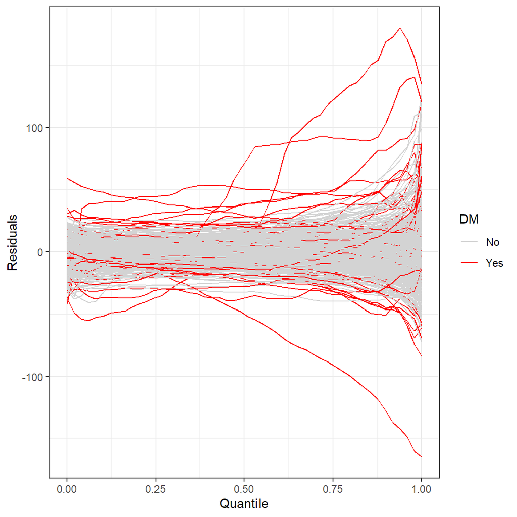

Figure 3.4: Residuals for the individuals with CGM measurements. Individuals with diabetes are shown in red.

```r
ggplot(cgm, aes(x = Quantile, y = Residuals, group = id)) +
  geom_line(aes(color = DM)) +
  scale_color_manual(values = c("lightgrey", "red")) +
  theme_bw()
```

After that, we fitted a linear model for the squared residuals as a function of the same covariates used in the missing data model (Age, Sex, HbA1c, FPG, Smoking, Albumin, and BMI). In Figure 3.5, the effect of these covariates on the squared residuals is depicted.

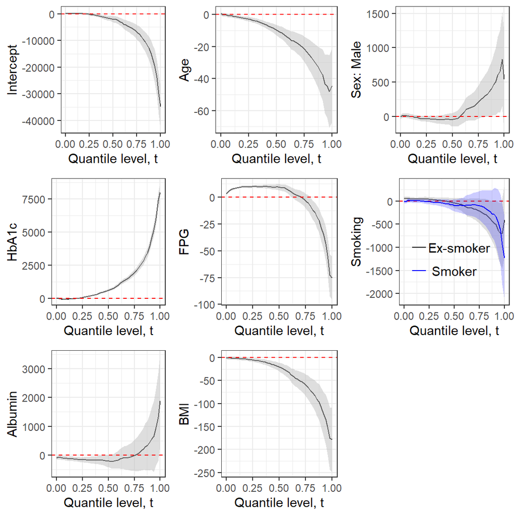

Figure 3.5: Estimated coefficients for the effects of Age, Sex, HbA1c, FPG, Smoking, Albumin, and BMI over the squared residuals.

```r
cgm_est1$Residuals <- Q - cgm_est1[, 5:54]
cgm_est1$Res_sq <- cgm_est1$Residuals^2
cgm_est1$sex <- as.numeric(cgm_est1$Sex) - 1

beta = matrix(0, nrow = px + 1, ncol = py)
upper = matrix(0, nrow = px + 1, ncol = py)
lower = matrix(0, nrow = px + 1, ncol = py)

xout_s = cgm_est1[, c("Age", "sex", "HbA1c", "FPG", "tab1", "tab2", "Albumin", "BMI")]
xout_s <- as.matrix(xout_s)
for(i in 1:py){
  maux =  lm(cgm_est1$Res_sq[, i] ~ xout_s[, 1] + xout_s[, 2] + xout_s[, 3] + xout_s[, 4] + xout_s[, 5] + xout_s[, 6] + xout_s[, 7] + xout_s[, 8], weights = cgm_est1$weights)
  beta[, i] = maux$coefficients
  upper[, i] = summary(maux)$coefficients[, 1] + summary(maux)$coefficients[, 2]
  lower[, i] = summary(maux)$coefficients[, 1] - summary(maux)$coefficients[, 2]
}

betas <- cbind.data.frame(t(beta), t(upper), t(lower), Qgrid)
names(betas)[1:dim(beta)[1]] <- paste0("v.", 1:dim(beta)[1])
names(betas)[(dim(beta)[1] + 1):(2*dim(beta)[1])] <- paste0("u.", 1:dim(beta)[1])
names(betas)[(2*dim(beta)[1] + 1):(3*dim(beta)[1])] <- paste0("l.", 1:dim(beta)[1])

g1 <- ggplot(data = betas, aes(x = Qgrid, y = v.1))+
  geom_line() +
  geom_ribbon(aes(ymin = l.1, ymax = u.1), fill = "grey",  alpha = 0.5) +
  theme_bw() +
  labs(x = "Quantile level, t", y = "Intercept") +
  geom_hline(aes(yintercept = 0), color="red",linetype = "dashed")

g2 <- ggplot(data = betas, aes(x = Qgrid, y = v.2))+
  geom_line() +
  geom_ribbon(aes(ymin = l.2, ymax = u.2), fill = "grey",  alpha = 0.5) +
  theme_bw() +
  labs(x = "Quantile level, t", y = "Age") +
  geom_hline(aes(yintercept = 0), color="red",linetype = "dashed")

g3 <- ggplot(data = betas, aes(x = Qgrid, y = v.3))+
  geom_line() +
  geom_ribbon(aes(ymin = l.3, ymax = u.3), fill = "grey",  alpha = 0.5) +
  theme_bw() +
  labs(x = "Quantile level, t", y = "Sex: Male") +
  geom_hline(aes(yintercept = 0), color="red",linetype = "dashed")

g4 <- ggplot(data = betas, aes(x = Qgrid, y = v.4))+
  geom_line() +
  geom_ribbon(aes(ymin = l.4, ymax = u.4), fill = "grey",  alpha = 0.5) +
  theme_bw() +
  labs(x = "Quantile level, t", y = "HbA1c") +
  geom_hline(aes(yintercept = 0), color="red",linetype = "dashed")

g5 <- ggplot(data = betas, aes(x = Qgrid, y = v.5))+
  geom_line() +
  geom_ribbon(aes(ymin = l.5, ymax = u.5), fill = "grey",  alpha = 0.5) +
  theme_bw() +
  labs(x = "Quantile level, t", y = "FPG") +
  geom_hline(aes(yintercept = 0), color="red",linetype = "dashed")

g6 <- ggplot(data = betas, aes(x = Qgrid, y = v.6))+
  geom_line() +
  geom_ribbon(aes(ymin = l.6, ymax = u.6), fill = "grey",  alpha = 0.5) +
  theme_bw() +
  labs(x = "Quantile level, t", y = "Smoking") +
  geom_hline(aes(yintercept = 0), color="red",linetype = "dashed") +
  geom_line(aes(x = Qgrid, y = v.7), color = "blue") +
  geom_ribbon(aes(ymin = l.7, ymax = u.7), fill = "blue",  alpha = 0.2) +
  annotate("text", x = 0.55, y = -1000, label= "Ex-smoker") +
  annotate("text", x = 0.5, y = -1500, label = "Smoker") +
  geom_segment(aes(x = 0.08, xend = 0.22, y = -1000, yend = -1000)) +
  geom_segment(aes(x = 0.08, xend = 0.22, y = -1500, yend = -1500), col = "blue")

g7 <- ggplot(data = betas, aes(x = Qgrid, y = v.8))+
  geom_line() +
  geom_ribbon(aes(ymin = l.8, ymax = u.8), fill = "grey",  alpha = 0.5) +
  theme_bw() +
  labs(x = "Quantile level, t", y = "Albumin") +
  geom_hline(aes(yintercept = 0), color="red",linetype = "dashed")

g8 <- ggplot(data = betas, aes(x = Qgrid, y = v.9))+
  geom_line() +
  geom_ribbon(aes(ymin = l.9, ymax = u.9), fill = "grey",  alpha = 0.5) +
  theme_bw() +
  labs(x = "Quantile level, t", y = "BMI") +
  geom_hline(aes(yintercept = 0), color="red",linetype = "dashed")

grid.arrange(g1, g2, g3, g4, g5, g6, g7, g8, p8, ncol = 3)
```

# 4 Using actual and estimated glucodensities from AEGIS-I for the survival free of diabetes (AEGIS-II)

In this Section, we use the quantiles of the glucodensities from AEGIS-I (580 real glucodensities and 936 estimated ones using the weighted linear regression model) in the estimation of the probability of survival free of diabetes using survival models.

First of all, we are going to keep only those individuals without diabetes in AEGIS-I, a total of 1333 subjects (87.93% of the sample).

```r
cgm_est$cgm  <- as.numeric(as.character(cgm_est$cgm))
name <- names(cgm_est)[1:4]

## Puting actual and estimated glucodensities in one matrix, Q
Q = cgm_est
for(i in 1:ny){
  if(cgm_est$cgm[i] == 1){
    Q[i, 5:(py + 4)] <- quantile(data1$Glucose[data1$ID == cgm_est$id[i]], probs = Qgrid)
  }else{
    Q[i, 5:(py + 4)] <- as.numeric(cgm_est[cgm_est$id[i], 5:(py + 4)])
  }
}
rm(i)
rm(data1)
Q <- as.data.frame(Q)
names(Q) <- c(name, paste0("p", 1:50))
rm(name)

data1_comp <- data1_id
data1_id <- data1_id[data1_id$DM == "No", ]
Q <- Q[Q$dm1 == 0, ]
```

Second, we are going to eliminate those individuals with a follow up of less than 6 months (or 0.5 years), a total of 40 subjects. In doing so, we now have a total of 1293 individuals.

```r
data1_id <- data1_id[data1_id$followup >= 0.5, ]
Q <- Q[Q$id %in% data1_id$ID, ]

data1_id$dm2_bin <- ifelse(is.na(data1_id$tipo_dm2), 0,
                    ifelse(data1_id$tipo_dm2 == "Pancreática", 0, data1_id$dm2_bin))
data1_id$Incidence <- ifelse(is.na(data1_id$tipo_dm2), 0,
                    ifelse(data1_id$tipo_dm2 == "Pancreática", 0, data1_id$dm_incidence))
```

In this sample, 789 individuals (61%) have imputed CGM. Below we show the summary of the follow-up time (in years) of the patients until the development of diabetes or the end of follow-up.

```r
summary(data1_id$followup)
```

```
##    Min. 1st Qu.  Median    Mean 3rd Qu.    Max.
##  0.5123  6.1836  7.4438  7.0156  8.3342  9.7342
```

In this sample, 75 individuals developed diabetes, an incidence of 5.8%. In Table 4.1, we show the summary of the predictor variables used in the analysis analysis of the survival free of diabetes, separated by the fact of developing diabetes or not.

```r
data1_id$DM_incidence <- ifelse(data1_id$Incidence == 0, "Not DM incidence", "DM incidence")

datos <- data1_id[, c("ID", "Sex", "Age", "BMI", "HbA1c", "Insulin", "DM_incidence")]
datos_dm <- datos[datos$DM_incidence == "DM incidence", ]
datos_no <- datos[datos$DM_incidence == "Not DM incidence", ]

tabla <- apply(datos[, c("Age", "BMI", "HbA1c", "Insulin")], 2, function(x){
  paste0(format(round(mean(x), 2), nsmall = 2), " (", format(round(sd(x), 2), nsmall = 2), ")")
})

tabla <- c(tabla, paste0(table(datos$Sex)[2], " (", format(round(prop.table(table(datos$Sex))[2]*100, 2), nsmall = 2), "%)"))

tabla1 <- apply(datos_no[, c("Age", "BMI", "HbA1c", "Insulin")], 2, function(x){
  paste0(format(round(mean(x), 2), nsmall = 2), " (", format(round(sd(x), 2), nsmall = 2), ")")
})

tabla1 <- c(tabla1, paste0(table(datos_no$Sex)[2], " (", format(round(prop.table(table(datos_no$Sex))[2]*100, 2), nsmall = 2), "%)"))

tabla <- cbind(tabla, tabla1)

tabla1 <- apply(datos_dm[, c("Age", "BMI", "HbA1c", "Insulin")], 2, function(x){
  paste0(format(round(mean(x), 2), nsmall = 2), " (", format(round(sd(x), 2), nsmall = 2), ")")
})

tabla1 <- c(tabla1, paste0(table(datos_dm$Sex)[2], " (", format(round(prop.table(table(datos_dm$Sex))[2]*100, 2), nsmall = 2), "%)"))

tabla <- cbind.data.frame(tabla, tabla1)
row.names(tabla) <- c("Age", "BMI", "HbA1c", "Insulin", "Sex: Male")
```

Table 4.1: Table 4.2: Summary of the predictor variables used in the analysis of the incidence of diabetes, for the whole sample and separated by the fact of having developed diabetes or not. We represent the means and the standard deviations (in brackets) of the continuous variables (Age, BMI, HbA1c, Insulin) for subjetcs with and without diabetes at the end of the study. For the categorical variable Sex, we include the absolute frequency and percentage (in brackets).

|  | Total sample | Not DM incidence | DM incidence |
| --- | --- | --- | --- |
| Age | 51.05 (17.26) | 50.60 (17.42) | 58.31 (12.37) |
| BMI | 27.86 (4.95) | 27.56 (4.82) | 32.66 (4.66) |
| HbA1c | 5.41 (0.33) | 5.38 (0.32) | 5.86 (0.32) |
| Insulin | 11.84 (7.11) | 11.45 (6.50) | 18.22 (12.04) |
| Sex: Male | 549 (42.46%) | 514 (42.20%) | 35 (46.67%) |

In Figure 4.1 we show the boxplots for the continuous variables for the overall data set, while in Figure 4.2 we show the boxplots for the continuous variables separating by the incidence of diabetes.

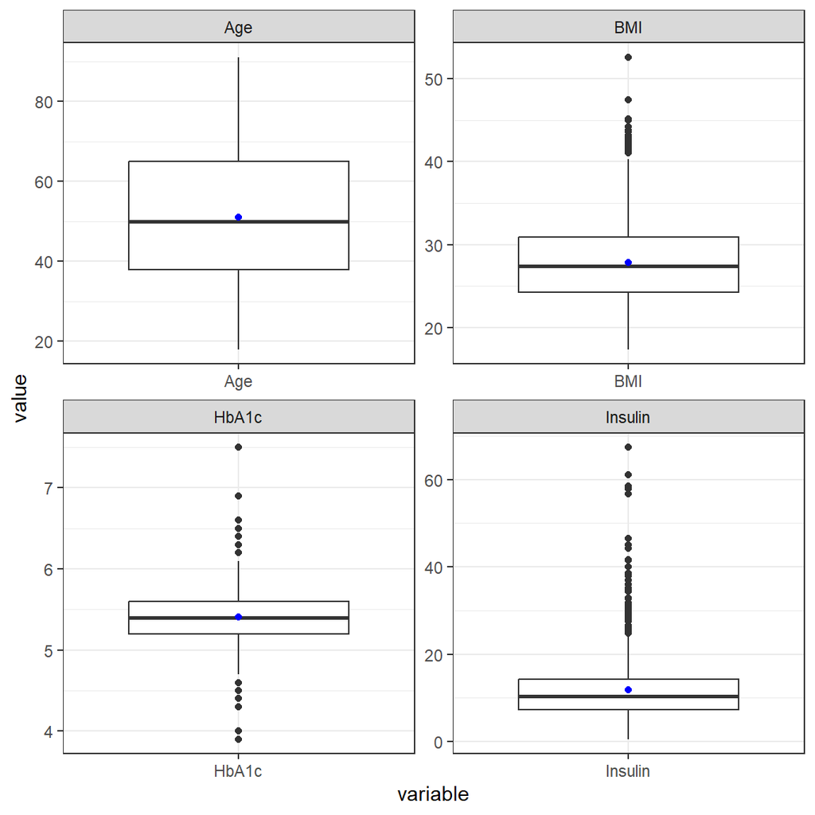

Figure 4.1: Boxplot for the continuous variables for the complete data set. The blue point indicates the mean value.

```r
plot_cont(datos[, c("Age", "BMI", "HbA1c", "Insulin")])
```

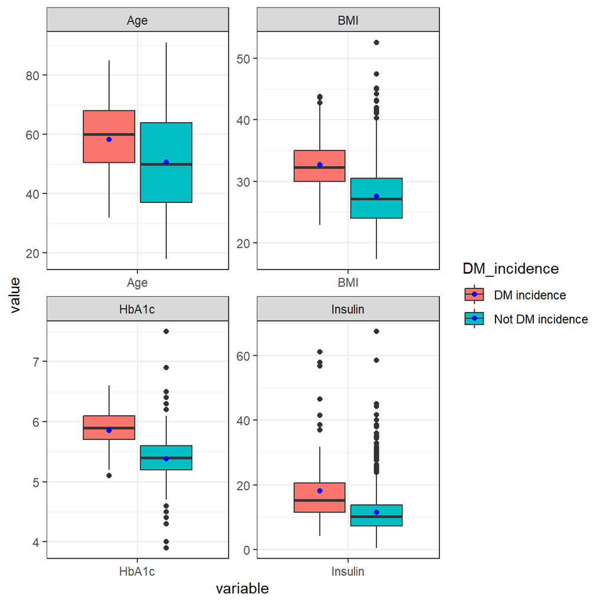

Figure 4.2: Boxplot for the continuous variables for the complete data set, separating by incidence of diabetes. The blue point indicates the mean value.

```r
plot_cont(datos[, c("Age", "BMI", "HbA1c", "Insulin")], datos$DM_incidence, nvar = "DM_incidence")
```

## 4.1 Computing functional PCA for the quantiles of the glucodensities

The first step is to calculate the functional principal components (fPCA) of the quantiles of the glucodensities, with the idea of using only the first ones as covariates to explain the incidence. In Figure 4.3 we can see the first five principal components for the quantiles of the glucodensities.

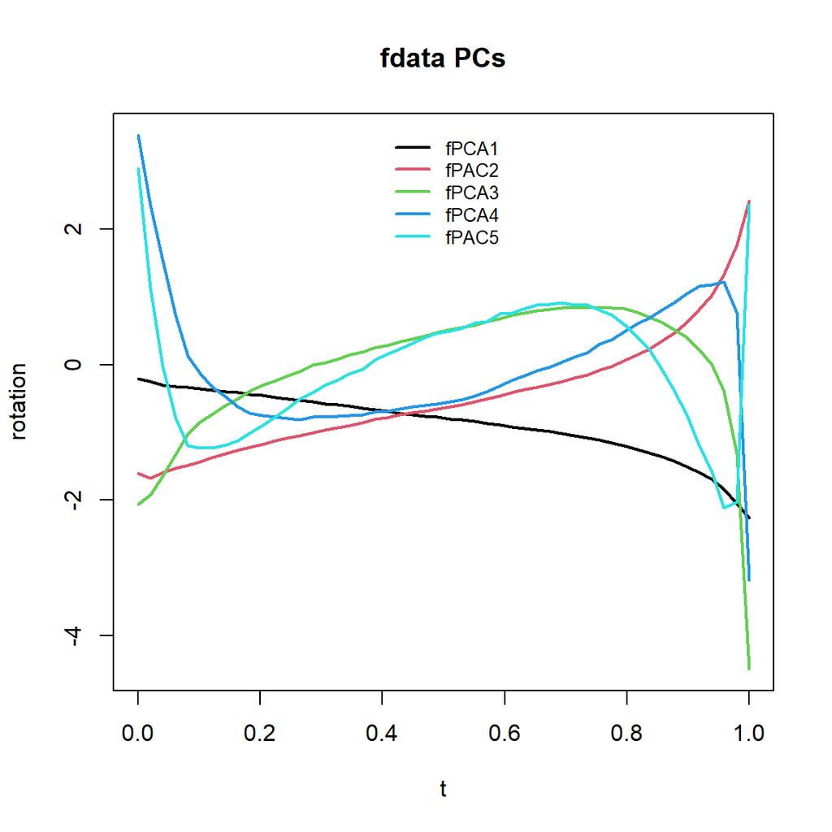

Figure 4.3: Estimated first 5 functional principal components (fPCA) of the glucodensities.

```r
gluco <- fdata(Q[, 5:dim(Q)[2]], argvals = Qgrid,
               names = list(main = "Glucodensities", xlab = "Prob", ylab = "Glucose levels"))
##' Computing the fPCA
res.pc <- fdata2pc(gluco, ncomp = 5)
pc3est <- res.pc$basis # Estimated PCA
plot(pc3est, lwd = 2, lty = 1, col = 1:5)
legend("top", c("fPCA1", "fPAC2", "fPCA3", "fPCA4", "fPAC5"), col = 1:5, lwd = 2, cex = 0.8, box.lty = 0, inset = 0.02)
```

If we take a look at the summary of the components, we can see that they explain the 99.42% of the glucodensities variability, and the first three alone (those explaining more than 1% of the variability) explain the 98.19%. As this percentage is extremely high, we are going to use only the first three fPCAs.

```r
summary(res.pc, biplot = F)
```

```
## [1] TRUE
##
##      - SUMMARY:   fdata2pc  object   -
##
## -With 5  components are explained  99.42 %
##  of the variability of explicative variables.
##
## -Variability for each component (%):
## [1] 83.51 12.63  2.05  0.86  0.37
```

```r
data1_id$pc1 <- res.pc$x[, 1]
data1_id$pc2 <- res.pc$x[, 2]
data1_id$pc3 <- res.pc$x[, 3]
data1_id$pc4 <- res.pc$x[, 4]
data1_id$pc5 <- res.pc$x[, 5]
```

## 4.2 Survival models for the risk of diabetes

In this section, we are going to estimate the risk of diabetes over time as a function of the functional principal components (fPCA) of the glucodensities, adjusting or not for other covariates, using an additive Cox regression model.

### 4.2.1 Using fPCA for the glucodensities as only covariates

As we did for the incidence of diabetes, we are starting by adjusting a model whose only covariates are the fPCA. All the effects are statistically significant.

```r
cox_pca_simple <- gam(followup ~ s(pc1) + s(pc2) + s(pc3), data = data1_id, family = cox.ph(), weights = Incidence)
summary(cox_pca_simple)
```

```
##
## Family: Cox PH
## Link function: identity
##
## Formula:
## followup ~ s(pc1) + s(pc2) + s(pc3)
##
## Approximate significance of smooth terms:
##          edf Ref.df Chi.sq  p-value
## s(pc1) 3.662  4.575 31.616 7.09e-06 ***
## s(pc2) 4.909  5.987 30.415 3.14e-05 ***
## s(pc3) 1.067  1.130  6.185   0.0192 *
## ---
## Signif. codes:  0 '***' 0.001 '**' 0.01 '*' 0.05 '.' 0.1 ' ' 1
##
## Deviance explained = 25.3%
## -REML =  436.6  Scale est. = 1         n = 1293
```

In Figure 4.4 we show the smooth effect of the three fPCAs.

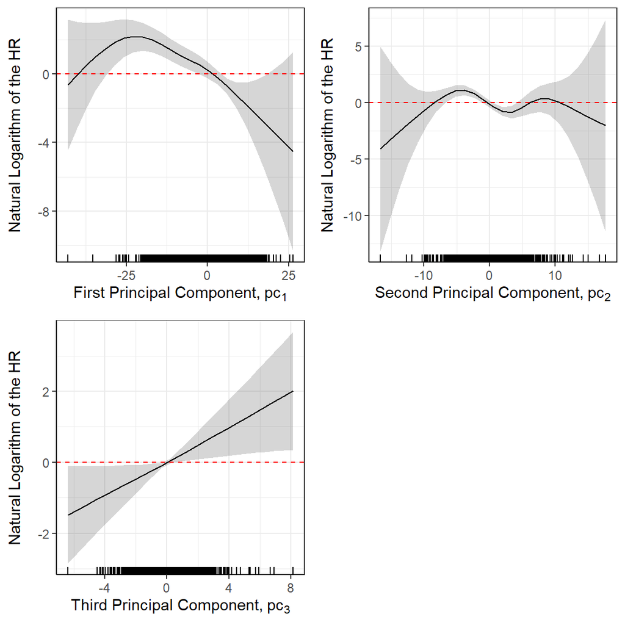

Figure 4.4: Smooth effect of the three fPCAs using P-splines.

```r
p_simple1 <- plot_smooths(
  model = cox_pca_simple,
  series = pc1) +
  geom_rug(data = data1_id, sides = "b",
           aes(x = pc1), inherit.aes = FALSE) +
  theme_bw() +
  theme(axis.line = element_line(colour = "black")) +
  theme(axis.line = element_line(colour = "black")
  ) +
  xlab(expression("First Principal Component,"~pc[1])) +
  ylab("Natural Logarithm of the HR") +
  geom_hline(yintercept = 0, linetype = "dashed", color = "red")

p_simple2 <- plot_smooths(
  model = cox_pca_simple,
  series = pc2) +
  geom_rug(data = data1_id, sides = "b",
           aes(x = pc2), inherit.aes = FALSE) +
  theme_bw() +
  theme(axis.line = element_line(colour = "black")) +
  theme(axis.line = element_line(colour = "black")
  ) +
  xlab(expression("Second Principal Component,"~pc[2])) +
  ylab("Natural Logarithm of the HR") +
  geom_hline(yintercept = 0, linetype = "dashed", color = "red")

p_simple3 <- plot_smooths(
  model = cox_pca_simple,
  series = pc3) +
  geom_rug(data = data1_id, sides = "b",
           aes(x = pc3), inherit.aes = FALSE) +
  theme_bw() +
  theme(axis.line = element_line(colour = "black")) +
  theme(axis.line = element_line(colour = "black")
  ) +
  xlab(expression("Third Principal Component,"~pc[3])) +
  ylab("Natural Logarithm of the HR")+
  geom_hline(yintercept = 0, linetype = "dashed", color = "red")

pnull <- ggplot() + theme_void()
plot_grid(p_simple1, p_simple2, p_simple3, pnull, ncol = 2,  align = "v")
```

### 4.2.2 Without fPCA for the glucodensities, only adjusting also for other covariates

Now, we are fitting the model without the fPCA as covariates, adjusting only for “Sex”, “Age”, “BMI”, “HbA1c”, and “Insulin”.

```r
cox <- gam(followup ~ Sex + s(Age) + s(BMI) + s(HbA1c) + s(Insulin), data = data1_id, family = cox.ph(), weights = Incidence)
summary(cox)
```

```
##
## Family: Cox PH
## Link function: identity
##
## Formula:
## followup ~ Sex + s(Age) + s(BMI) + s(HbA1c) + s(Insulin)
##
## Parametric coefficients:
##         Estimate Std. Error z value Pr(>|z|)
## SexMale  0.09173    0.25137   0.365    0.715
##
## Approximate significance of smooth terms:
##              edf Ref.df Chi.sq p-value
## s(Age)     2.101  2.667  4.376 0.20836
## s(BMI)     2.319  2.967 12.428 0.00616 **
## s(HbA1c)   3.616  4.484 90.207 < 2e-16 ***
## s(Insulin) 1.000  1.001  0.178 0.67324
## ---
## Signif. codes:  0 '***' 0.001 '**' 0.01 '*' 0.05 '.' 0.1 ' ' 1
##
## Deviance explained = 31.5%
## -REML = 417.33  Scale est. = 1         n = 1293
```

In Figure 4.5 we show the smooth effects of the covariates in the model without the fPCAs.

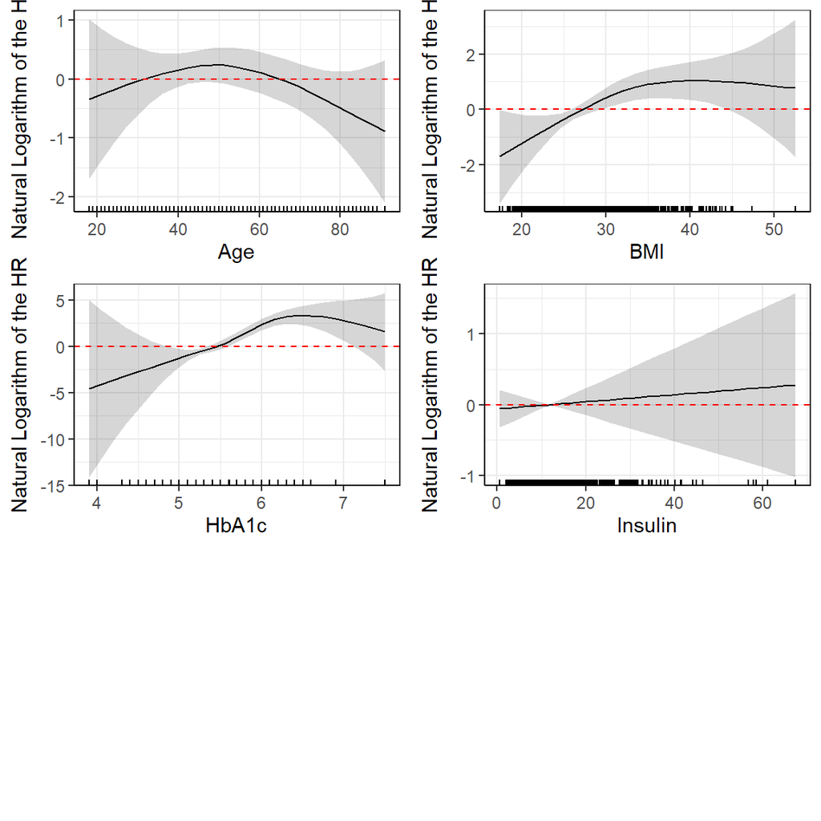

Figure 4.5: Effect of smooth continuous covariates in the model without the fPCAs.

```r
p1 <- plot_smooths(
  model = cox,
  series = Age,
  conditions = quos(Sex == "Female")) +
  geom_rug(data = data1_id, sides = "b",
           aes(x = Age), inherit.aes = FALSE) +
  theme_bw() +
  theme(axis.line = element_line(colour = "black"),
        legend.position = "none") +
  xlab("Age") +
  ylab("Natural Logarithm of the HR") +
  geom_hline(yintercept = 0, linetype = "dashed", color = "red")

p2 <- plot_smooths(
  model = cox,
  series = BMI,
  conditions = quos(Sex == "Female")) +
  geom_rug(data = data1_id, sides = "b",
           aes(x = BMI), inherit.aes = FALSE) +
  theme_bw() +
  theme(axis.line = element_line(colour = "black"),
        legend.position = "none") +
  xlab("BMI") +
  ylab("Natural Logarithm of the HR") +
  geom_hline(yintercept = 0, linetype = "dashed", color = "red")

p3 <- plot_smooths(
  model = cox,
  series = HbA1c,
  conditions = quos(Sex == "Female")) +
  geom_rug(data = data1_id, sides = "b",
           aes(x = HbA1c), inherit.aes = FALSE) +
  theme_bw() +
  theme(axis.line = element_line(colour = "black"),
        legend.position = "none") +
  xlab("HbA1c") +
  ylab("Natural Logarithm of the HR") +
  geom_hline(yintercept = 0, linetype = "dashed", color = "red")

p4 <- plot_smooths(
  model = cox,
  series = Insulin,
  conditions = quos(Sex == "Female")) +
  geom_rug(data = data1_id, sides = "b",
           aes(x = Insulin), inherit.aes = FALSE) +
  theme_bw() +
  theme(axis.line = element_line(colour = "black"),
        legend.position = "none") +
  xlab("Insulin") +
  ylab("Natural Logarithm of the HR") +
  geom_hline(yintercept = 0, linetype = "dashed", color = "red")

plot_grid(p1, p2, p3, p4, pnull, ncol = 2,  align = "v")
```

### 4.2.3 fPCA for the glucodensities, adjusting also for other covariates

Finally, we are fitting the model with the fPCA as covariates, adjusting also for Sex, Age, BMI, HbA1c and Insuline.

```r
cox_pca <- gam(followup ~ Sex + s(Age) + s(BMI) + s(HbA1c) + s(Insulin) + s(pc1) + s(pc2) + s(pc3), data = data1_id, family = cox.ph(), weights = Incidence)
summary(cox_pca)
```

```
##
## Family: Cox PH
## Link function: identity
##
## Formula:
## followup ~ Sex + s(Age) + s(BMI) + s(HbA1c) + s(Insulin) + s(pc1) +
##     s(pc2) + s(pc3)
##
## Parametric coefficients:
##         Estimate Std. Error z value Pr(>|z|)
## SexMale  -0.1636     0.2648  -0.618    0.537
##
## Approximate significance of smooth terms:
##              edf Ref.df Chi.sq  p-value
## s(Age)     1.638  2.057  9.049 0.011539 *
## s(BMI)     1.768  2.251 15.391 0.000774 ***
## s(HbA1c)   1.927  2.480 15.175 0.001498 **
## s(Insulin) 1.000  1.000  0.158 0.691406
## s(pc1)     3.829  4.769 17.908 0.003008 **
## s(pc2)     4.244  5.263 12.041 0.046850 *
## s(pc3)     1.000  1.000  0.475 0.491028
## ---
## Signif. codes:  0 '***' 0.001 '**' 0.01 '*' 0.05 '.' 0.1 ' ' 1
##
## Deviance explained =   37%
## -REML = 408.83  Scale est. = 1         n = 1293
```

In Figure 4.6 we show the smooth effects of the covariates in the complete model.

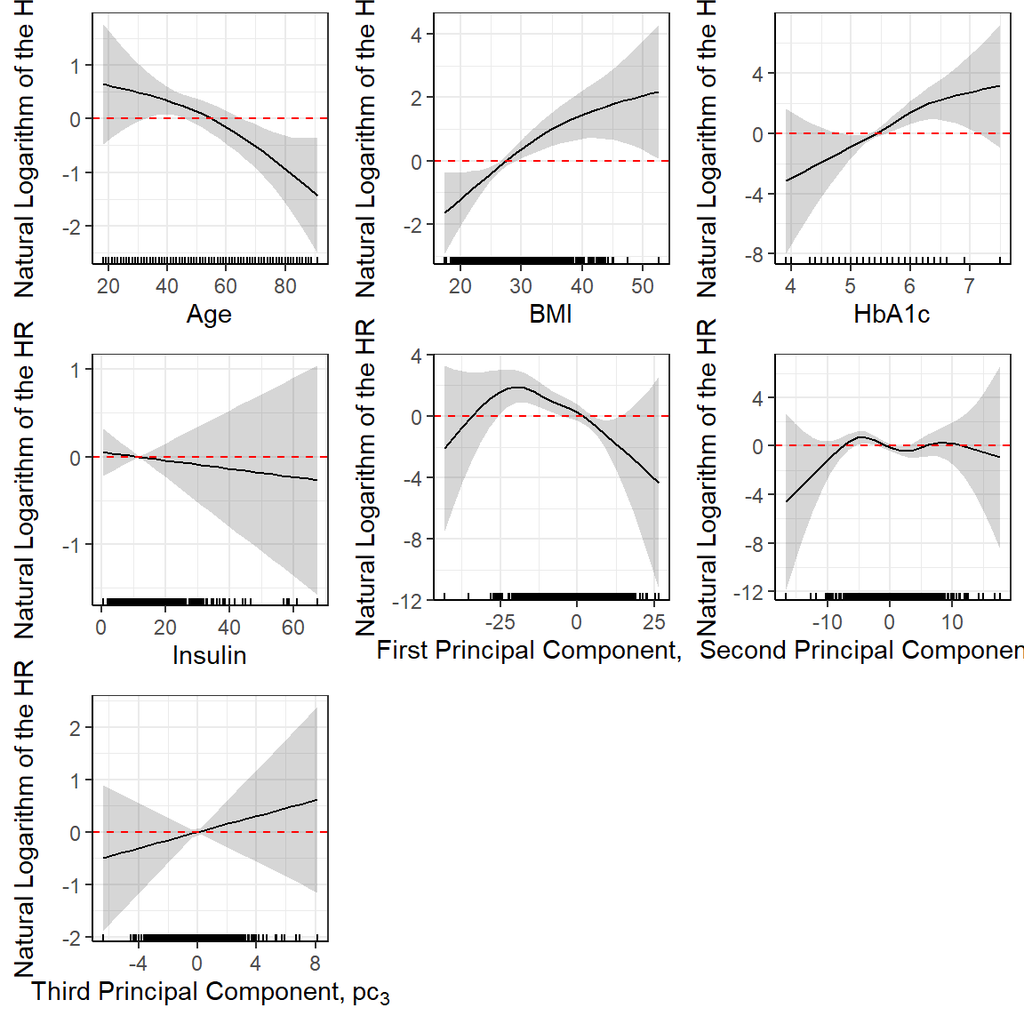

Figure 4.6: Effect of smooth continuous covariates in the complete model.

```r
p1 <- plot_smooths(
  model = cox_pca,
  series = Age,
  conditions = quos(Sex == "Female")) +
  geom_rug(data = data1_id, sides = "b",
           aes(x = Age), inherit.aes = FALSE) +
  theme_bw() +
  theme(axis.line = element_line(colour = "black"),
        legend.position = "none") +
  xlab("Age") +
  ylab("Natural Logarithm of the HR") +
  geom_hline(yintercept = 0, linetype = "dashed", color = "red")

p2 <- plot_smooths(
  model = cox_pca,
  series = BMI,
  conditions = quos(Sex == "Female")) +
  geom_rug(data = data1_id, sides = "b",
           aes(x = BMI), inherit.aes = FALSE) +
  theme_bw() +
  theme(axis.line = element_line(colour = "black"),
        legend.position = "none") +
  xlab("BMI") +
  ylab("Natural Logarithm of the HR") +
  geom_hline(yintercept = 0, linetype = "dashed", color = "red")

p3 <- plot_smooths(
  model = cox_pca,
  series = HbA1c,
  conditions = quos(Sex == "Female")) +
  geom_rug(data = data1_id, sides = "b",
           aes(x = HbA1c), inherit.aes = FALSE) +
  theme_bw() +
  theme(axis.line = element_line(colour = "black"),
        legend.position = "none") +
  xlab("HbA1c") +
  ylab("Natural Logarithm of the HR") +
  geom_hline(yintercept = 0, linetype = "dashed", color = "red")

p4 <- plot_smooths(
  model = cox_pca,
  series = Insulin,
  conditions = quos(Sex == "Female")) +
  geom_rug(data = data1_id, sides = "b",
           aes(x = Insulin), inherit.aes = FALSE) +
  theme_bw() +
  theme(axis.line = element_line(colour = "black"),
        legend.position = "none") +
  xlab("Insulin") +
  ylab("Natural Logarithm of the HR") +
  geom_hline(yintercept = 0, linetype = "dashed", color = "red")

p5 <- plot_smooths(
  model = cox_pca,
  series = pc1,
  conditions = quos(Sex == "Female")) +
  geom_rug(data = data1_id, sides = "b",
           aes(x = pc1), inherit.aes = FALSE) +
  theme_bw() +
  theme(axis.line = element_line(colour = "black"),
        legend.position = "none") +
  xlab(expression("First Principal Component,"~pc[1])) +
  ylab("Natural Logarithm of the HR") +
  geom_hline(yintercept = 0, linetype = "dashed", color = "red")

p6 <- plot_smooths(
  model = cox_pca,
  series = pc2,
  conditions = quos(Sex == "Female")) +
  geom_rug(data = data1_id, sides = "b",
           aes(x = pc2), inherit.aes = FALSE) +
  theme_bw() +
  theme(axis.line = element_line(colour = "black"),
        legend.position = "none") +
  xlab(expression("Second Principal Component,"~pc[2])) +
  ylab("Natural Logarithm of the HR") +
  geom_hline(yintercept = 0, linetype = "dashed", color = "red")

p7 <- plot_smooths(
  model = cox_pca,
  series = pc3,
  conditions = quos(Sex == "Female")) +
  geom_rug(data = data1_id, sides = "b",
           aes(x = pc3), inherit.aes = FALSE) +
  theme_bw() +
  theme(axis.line = element_line(colour = "black"),
        legend.position = "none") +
  xlab(expression("Third Principal Component,"~pc[3])) +
  ylab("Natural Logarithm of the HR") +
  geom_hline(yintercept = 0, linetype = "dashed", color = "red")

plot_grid(p1, p2, p3, p4, p5, p6, p7, pnull, ncol = 3,  align = "v")
```

## 4.3 Comparing the three models in terms of AUC over time

In this subsection we are comparing the three models to see the differences in discrimination between all of them. For this, we are going to use de AUC curve over time. In Figure 4.7 we can see the AUC curves over time for the three models.

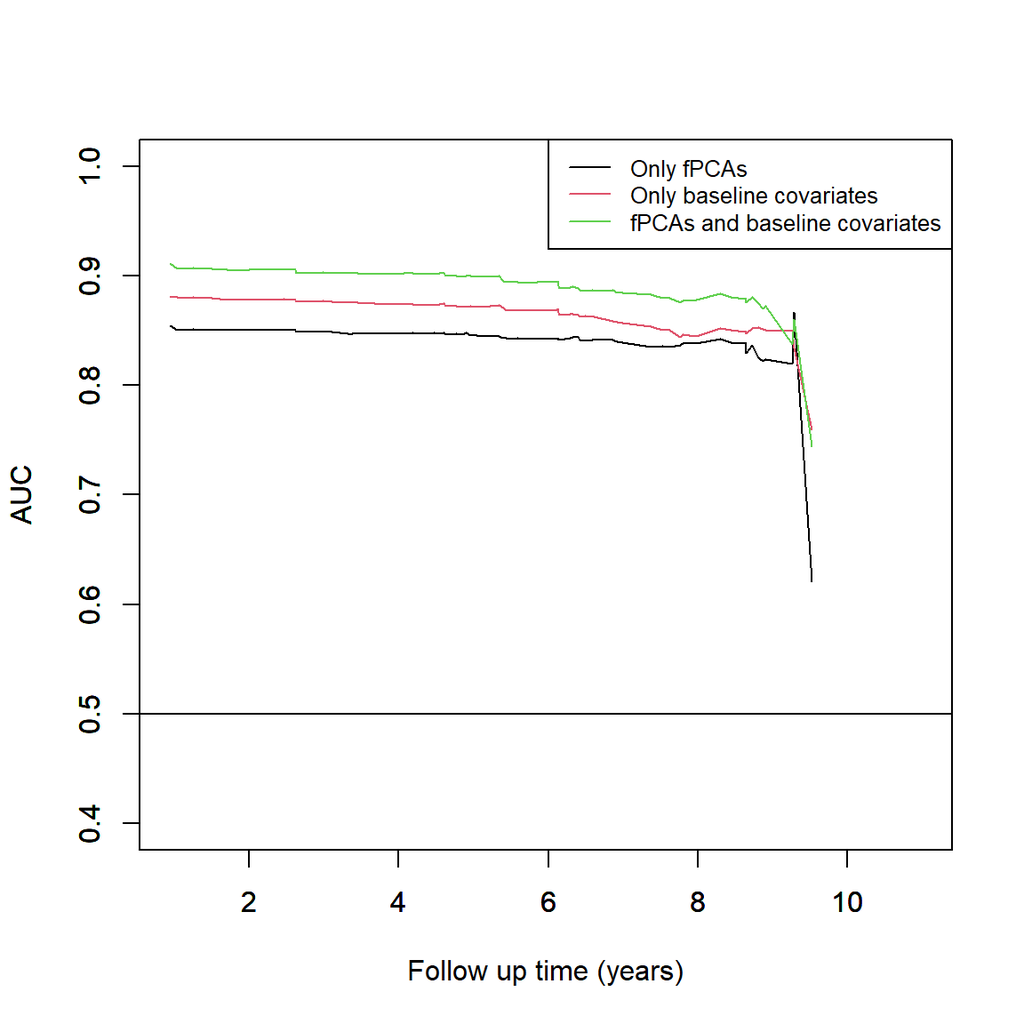

Figure 4.7: AUC curves for the three survival models considered.

```r
auc1 <- risksetAUC(data1_id$followup, status = data1_id$Incidence, tmax = 10, marker = cox_pca_simple$linear.predictors,
                   xlab = "Follow up time (years)", main = "")
par(new = TRUE)
auc2 <- risksetAUC(data1_id$followup, status = data1_id$Incidence, tmax = 10, marker = cox$linear.predictors,
                   col = 2, xlab = " ")
par(new = TRUE)
auc3 <- risksetAUC(data1_id$followup, status = data1_id$Incidence, tmax = 10, marker = cox_pca$linear.predictors,
                   col = 3, xlab = " ")

legend("topright", legend = c("Only fPCAs", "Only baseline covariates", "fPCAs and baseline covariates"), lwd = 1,
       col = c(1, 2, 3), cex = 0.8)
```

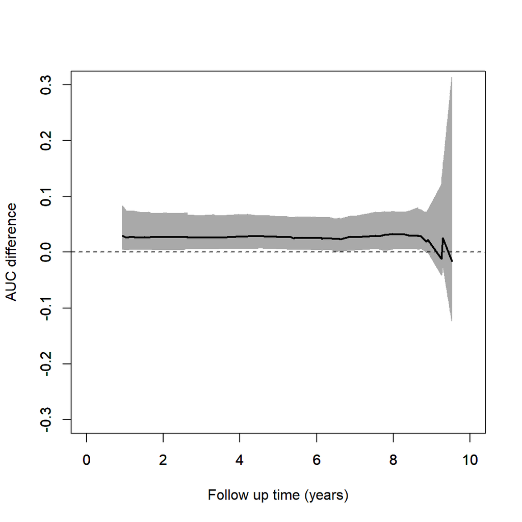

Figure 4.8: Difference of AUC over time of the full model with respect to the model without functional covariates. The 95% confidence interval calculated by bootstrap resampling with 1000 samples is shown in grey.

```r
auc <- auc3$AUC - auc2$AUC

B = 1000
AUC <- matrix(rep(0, l = length(auc)*B), nrow = B)
set.seed(12345)
for(l in 1:B){
  data.a <- bootstrap.sample(data1_id)
    mod.a <- gam(followup ~ Sex + s(Age) + s(BMI) + s(HbA1c) + s(Insulin), data = data.a, family = cox.ph(), weights = Incidence)

  mod.b <- gam(followup ~ Sex + s(Age) + s(BMI) + s(HbA1c) + s(Insulin) + s(pc1) + s(pc2) + s(pc3), data = data.a, family = cox.ph(), weights = dm_incidence)

  data.a$eta1 <- mod.a$linear.predictors
  data.a$eta2 <- mod.b$linear.predictors
  #
  out1 <- risksetAUC(data.a$followup, status = data.a$Incidence, marker = data.a$eta1, tmax = 10,
                     plot = F, predict.time = 0.5)
  #
  out2 <- risksetAUC(data.a$followup, status = data.a$Incidence, marker = data.a$eta2, tmax = 10,
                     plot = F, predict.time = 0.5)
  #
  difauc <- out2$AUC - out1$AUC
  for(k in 1:length(auc2$utimes)){
    AUC[l, k] <- interpolate(out2$utimes, difauc, auc2$utimes[k])
  }
}

ci <- apply(AUC, 2, quantile, probs = c(0.025, 0.975))

plot(auc2$utimes, auc, lwd = 2, type = "l", ylim = c(-0.3, 0.3), main = "",
     xlab = "Follow up time (years)", ylab = "AUC difference", xlim = c(0, 10))
par(new = TRUE)
plot(auc2$utimes, ci[1, ],lwd = 1, lty = 2, type = "l", ylab = "", xlab = "",
     ylim = c(-0.3, 0.3), xlim = c(0, 10), col = 'darkgray')
par(new = TRUE)
plot(auc2$utimes, ci[2, ], lwd = 1, lty = 2, type = "l", ylab = "", xlab = "",
     ylim = c(-0.3, 0.3), xlim = c(0, 10), col = 'darkgray')

cord.x <- c(auc2$utimes, auc2$utimes[length(auc2$utimes):1])
cord.y <- c(ci[1, 1:length(auc2$utimes)], ci[2,length(auc2$utimes):1])
polygon(cord.x, cord.y, col = 'darkgray', border = "darkgray")
abline(h = 0, lty = "dashed")
lines(auc2$utimes, auc, lwd = 2, type = "l", xlim = c(0, 10))
```

# 5 Using actual and estimated glucodensities from AEGIS-I for the survival free of diabetes (AEGIS-II). Testing the adequacy of estimates according to conformal confidence bands

In this Section, we perform the missing data model fit for the quantiles of the glucodensities on the 580 AEGIS-I subjects at baseline to imput the glucodensities on the remaining 936 subjects. Then, we use the use these quantiles functions from AEGIS-I in the estimation of the probability of survival free of diabetes.

The novelty here with respect to what we did in the previous Section is that we will use one part of the sample for the estimation of the quantiles of the glucodensities and the other part for the calculation of the confidence bands for this estimation. Once the bands are obtained, we will keep only those imputations whose maximum radius of the bands is smaller than the given radius. In doing so, we aim to eliminate estimates with higher uncertainty, as they are perceived as less “reliable”. We will test with different radii to try to obtain an optimal cut-off point for this radius, measured in terms of the AUC over time of the survival models where we will use these imputations, as well as their corresponding C index. The survival model chosen is *cox_pca*), since it was proven to be the best model for estimate the probability of survival free of diabetes.

## 5.1 Fitting the missing data model

The process is very similar to the one in the previous Section, using the same individuals, the same covariates and the same weights. As we already mentioned, in this case we use a third of the sample with known CGM for the estimation of the quantiles of the glucodensities and the other two thirds for the estimation of 95% confidence bands, using conformal inference.

```r
colnames(Qin) = paste("Q", 1:py, sep = "")
data1_comp$Q = Qin

dat0 <- data1_comp[data1_comp$cgm == 0, ] # The ones we want to imput
dat1 <- data1_comp[data1_comp$cgm == 1, ] # Train dataset
```

```r
set.seed(123)
m <- concurrentconformal(formula = "Q ~ Age + sex + HbA1c + FPG + tab1 + tab2 + BMI + Albumin", prob = 0.95, xpred = dat0, var_weights = weights, data = dat1, plot = F)
```

```r
dat0$Q <- m$Yest
for(i in 1:dim(data1_comp)){
  for(j in 1:dim(dat0)){
    if(data1_comp$ID[i] == dat0$ID[j]){
      data1_comp$Q[i, ] <- dat0$Q[j, ]
    }
  }
}

radio <- (m$upper - m$lower)/2
radio <- apply(radio, 1, max)
data1_comp$radio <- 0
data1_comp$radio[data1_comp$cgm == 0] <- radio
```

Now, we consider only the 1293 individuals with no diabetes in AEGIS-I, and also with a followup time larger than 6 months (half a year), 504 of whom have CGM.

```r
data1_id <- merge(data1_id, data1_comp[, c("ID", "radio", "Q")], by = "ID", all.x = T)
```

Below, we show the summary for the maximum radius, with a balanced separation or the training set.

```r
summary(data1_id$radio[data1_id$cgm == 0])
```

```
##    Min. 1st Qu.  Median    Mean 3rd Qu.    Max.
##   72.27  143.78  186.72  181.22  215.99  369.24
```

Given the summary of the radios, the grid of radios we propose is the following:

```r
grid_radios <- c(0, seq(80, 200, by = 10), 370)
grid_radios
```

```
##  [1]   0  80  90 100 110 120 130 140 150 160 170 180 190 200 370
```

## 5.2 Fitting the survival model for different radii

In this Section we are going to fit the complete survival model from the previous Section including only those imputed values whose confidence bands have a maximum radius equal or less than a given radius, from a grid of radii.

```r
n <- length(grid_radios)

nsample <- numeric(n)
times <- vector(mode = 'list', length = n)
AUC <- vector(mode = 'list', length = n)
C <- numeric(n)

for(i in 1:n){
  dat <- data1_id[data1_id$radio <= grid_radios[i], ]
  nsample[i] <- dim(dat)[1]

  ### Computing the PCAs
  gluco <- fdata(dat$Q, argvals = Qgrid, names = list(main = "Glucodensities", xlab = "Prob", ylab = "Glucose levels"))
  ##' Computing the fPCA
  res.pc <- fdata2pc(gluco, ncomp = 3)
  pc3est <- res.pc$rotation # Estimated PCA
  dat$pc1 <- res.pc$x[, 1]
  dat$pc2 <- res.pc$x[, 2]
  dat$pc3 <- res.pc$x[, 3]

  cox_pca <- gam(followup ~ Sex + s(Age) + s(BMI) + s(HbA1c) + s(Insulin) + s(pc1) + s(pc2) + s(pc3), data = dat, family = cox.ph(), weights = Incidence)
  auc <- risksetAUC(dat$followup, status = dat$Incidence, tmax = 10, marker = cox_pca$linear.predictors, predict.time = 0.5, plot = F)
  times[[i]] <- auc$utimes
  AUC[[i]] <- auc$AUC
  C[i] <- auc$Cindex
}
rm(i)
rm(dat)
rm(auc)
rm(gluco)
rm(res.pc)
rm(pc3est)
```

In Table 5.1 we show the C index obtained for each subset, considering only the imputed quantiles of the glucodensities which a maximum radio for the confidence bands no larger than the given radio. We also show the number of subjects chosen for each radio.

Table 5.1: Table 5.2: C statistics for the survival models with the different subsets depending on the maximum radio of the confidence bands of the glucodensities, and the number of subjects.

[output not shown]

In Table 5.1 we can see that the higher value of the C index is for a radio of 110, i.e., including 62 of the individuals with imputed CGM. In Figure 5.1 we can see the AUC over time for all the given radii

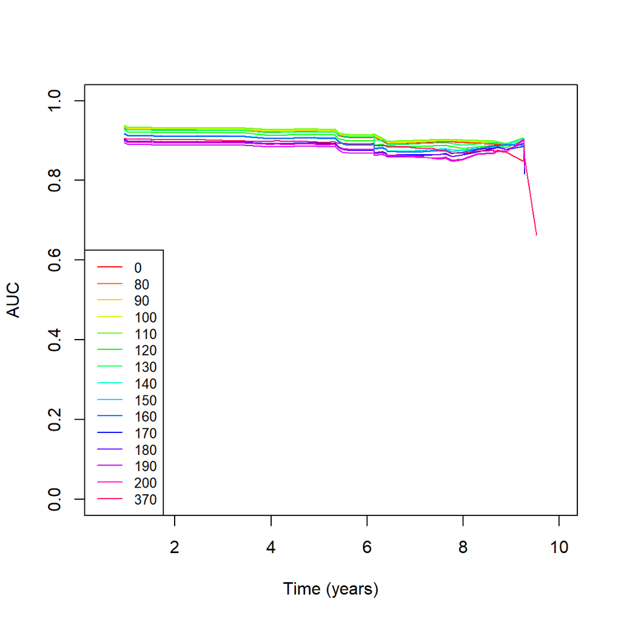

Figure 5.1: AUC over time for survival models with the different subsets depending on the maximum radius of the confidence bands of the quantiles of the glucodensities

```r
xmin <- min(unlist(lapply(times, min)))
xmax <- max(unlist(lapply(times, max)))
xtime <- c(0.5, 10)

plot(AUC[[1]] ~ times[[1]], xlim = xtime, ylim = c(0, 1), col = rainbow(n)[1], xlab = "Time (years)", ylab = "AUC", type = "l")

for(i in 2:n){
  lines(AUC[[i]] ~ times[[i]], col = rainbow(n)[i])
}

legend("bottomleft", legend = grid_radios, lwd = 1, col = rainbow(n), cex = 0.8)
```

# Bibliography

Wood, S. N. (2017), *Generalized additive models: An introduction with R*, CRC press. https://doi.org/10.1201/9781420010404.